# EDA

# Motivation

Roughly 80 percent of college students in the United States change their major at least once before graduating, according to the National Center for Education Statistics. While every college student has to choose a major of study, there are few established rules of thumb to help make this decision. However, often the potential for financial security and upward economic mobility can weigh heavily. For students to gather job prospect information for their major, they could consult with professors, alumni, peers, and other anecdotal sources of information.

# Exploring the data

FiveThirtyEight’s data is split up into several data frames. The one of most interest to us is recent_grads, which contains economic information on college graduates under the age of 28 for every major. Most of the figures (such as those for unemployment rate by major and number of graduates by gender) are based on totals gathered by the U.S. Census Bureau. However, earnings figures are calculated from a survey, and included from people working full-time (35 hours per week or more) and year-round (50 weeks per year or more). Because the earnings statistics are derived from a survey, the sample size of respondents for each major is sometimes lower than 100 – but as FiveThirtyEight’s Ben Casselman notes, there is still enough information to denote a general income ranking for majors and major categories. Additionally, because the dataset lacks demographic information on individuals, we can only say that higher incomes are associated with certain majors – lacking the ability to make a controlled comparison, it is more difficult to point out one’s chosen major as the cause of their income. That said, we can still discover some interesting trends and considerations to guide students.

The recent_grads dataset has 173 rows and 21 columns. Each case is a different college major. The salary figures mentioned above track information from 61,602 different individuals, working a variety of jobs labeled as “college jobs”, “non college jobs”, and “low wage jobs”. There are also figures on the share of women graduates for each major, as well as some other employment and income information. Let’s now explore the data in more detail to find useful statistics for students deciding on a major.

[output not shown]

```r
#Top five and bottom five majors for median earnings:

topfiveearners <- recent_grads %>%
  select(Rank, Major, Median) %>%
  filter(Rank <= 5)
```

[output not shown]

```r
bottomfiveearners <- recent_grads %>%
  select(Rank, Major, Median) %>%
  filter(Rank >= max(Rank) - 4)
```

A quick look at the data set reveals that the top earning majors are primarily in engineering, which captured 17 of the top 20 highest median salary spots. In contrast, the bottom ranks are more varied but are mostly in the non-STEM and psychology/social work fields. For students who are still unsure about which major categories to look into to begin with, it is helpful to examine salaries aggregated by major category. We can visualize this with the following plot:

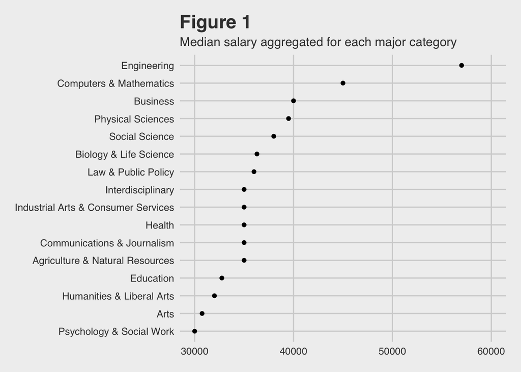

The plot confirms that engineering majors make the most, while psychology and social work majors make the least: the median income for engineering majors ($57,000) is nearly twice that of graduates with degrees in psychology and social work ($30,000). However, the middle eight major categories have similar median incomes, which could be good news for someone trying to choose between them – one could feel free to weigh other criteria in that case.

Next, we can examine the full-time employment rate for recent graduates. This is also important, because it suggests the financial security provided by various major categories.

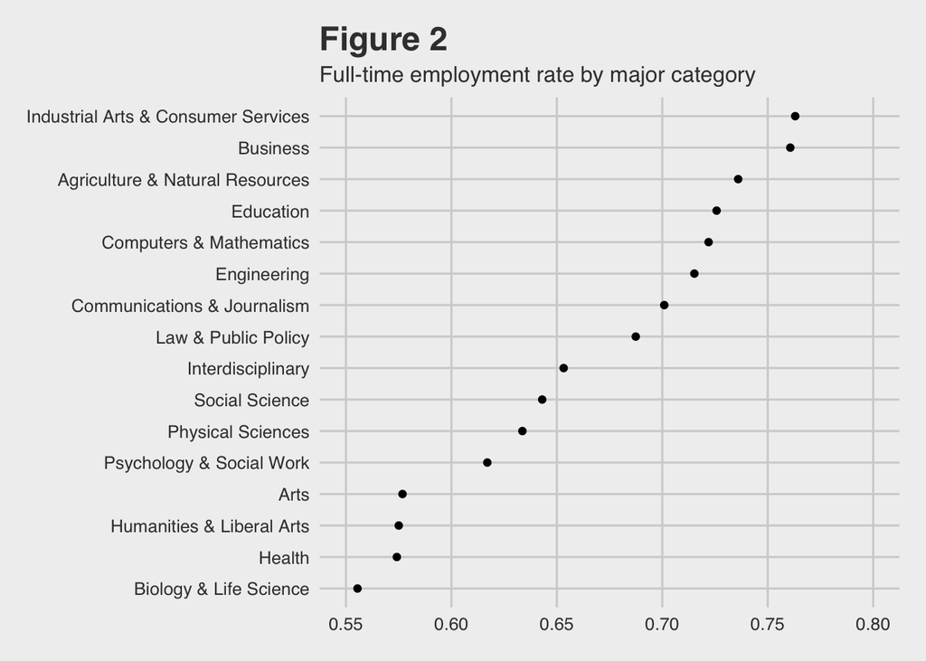

Our dataset cannot document the career trajectory of working individuals – for example, these statistics may overlook individuals who have been employed full-time for most of their post-college life, except for when they took the survey. However, the data can provide a snapshot of how likely a recent grad is to have a full-time job at any given time before the age of 28. This reveals some interesting figures. Many politicians tout the importance of STEM education, for instance, and students graduating with a degree in the biology and life sciences category have the 6th highest median salaries out of all the 16 major fields. However, they are also employed full-time at the lowest rate among all the major categories, at 56 percent. Also, zoology has the fifth lowest median income of all majors, which is an outlier compared to other life sciences but also demonstrates that science majors are not guaranteed a high income in every case. In contrast, graduates with degrees in education have relatively low median incomes but are employed full-time at the fourth highest rate of all major categories. Clearly, students would not be getting the full story if they based their major decision on either median income or the full-time employment rate alone, rather than both statistics and other relevant factors as well.

With all that said, it can still be daunting for a student early in their college career to start thinking about choosing a major. We created a tool that suggests a broad major category based on one’s desired post-college economic outcomes, which can help to inform students at the earliest parts of the decision process. You can explore this suggester tool and create your own plots in the other tabs.